# Homework 6: STAT 417 - Survival Analysis Methods

Author

Andrew Kerr

# Custom Function

```r
CI <- function(i, j, a, b, z, cox_reg_obj) {

  betas <- cox_reg_obj$coefficients

  B <- a*betas[[i]] + b*betas[[j]]

  cov_matrix <- cox_reg_obj$var

  V_hat <- (
    a**2 * cov_matrix[i, i] +
    b**2 * cov_matrix[j, j] +
    2*a*b * cov_matrix[i, j]
  )

  SE <- sqrt(V_hat)

  rev(exp(B %+-% z * SE))

}
```

# Problem 1

The Mexico Covid19 data file, `Mex.Covid.txt`, is located in the Homework 6 folder. The time-to-event variable will be defined as $T = \text{time (days)}$ from first symptom of Covid-19 until death for those individuals who test positive for SARS-COV2. Define the following variables:

- **TTD**: Time (in days) from first symptom of COVID-19 until death
- **Censor**: Takes the value 1 if the individual experienced death; 0 if the individual did not die by September 27th, 2020
- **Gender**: $X_1 = 1$ if male, $X_1 = 0$ if female
- **Age**: $X_2 =$ Age (in years) of the person who tested positive
- **Asthma**: $X_3 = 1$ if the person has asthma, 0 otherwise
- **Obese**: $X_4 = 1$ if the person is obese, 0 otherwise

Import the data and remove individuals with “Unknown” values for Obese and Asthma using:

```r
Mex.Covid <- Mex.Covid[Mex.Covid$Obese!="Unknown",]
Mex.Covid <- Mex.Covid[Mex.Covid$Asthma!="Unknown",]
```

Fit the Cox regression model:

```r
cr.obj <- coxph(Surv(TTD,Censor)~as.factor(Gender)+Age+as.factor(Asthma)+as.factor(Obese), data=Mex.Covid)
summary(cr.obj)
```

```
Call:
coxph(formula = Surv(TTD, Censor) ~ as.factor(Gender) + Age +
    as.factor(Asthma) + as.factor(Obese), data = Mex.Covid)

  n= 174659, number of events= 67225
   (554794 observations deleted due to missingness)

                           coef exp(coef)  se(coef)      z Pr(>|z|)
as.factor(Gender)Male 0.1986521 1.2197575 0.0080774  24.59   <2e-16 ***
Age                   0.0299128 1.0303647 0.0002702 110.71   <2e-16 ***
as.factor(Asthma)Yes  0.1882657 1.2071542 0.0080944  23.26   <2e-16 ***
as.factor(Obese)Yes   0.3166279 1.3724918 0.0122048  25.94   <2e-16 ***
---
Signif. codes:  0 '***' 0.001 '**' 0.01 '*' 0.05 '.' 0.1 ' ' 1

                      exp(coef) exp(-coef) lower .95 upper .95
as.factor(Gender)Male     1.220     0.8198     1.201     1.239
Age                       1.030     0.9705     1.030     1.031
as.factor(Asthma)Yes      1.207     0.8284     1.188     1.226
as.factor(Obese)Yes       1.372     0.7286     1.340     1.406

Concordance= 0.644  (se = 0.001 )
Likelihood ratio test= 17375  on 4 df,   p=<2e-16
Wald test            = 16423  on 4 df,   p=<2e-16
Score (logrank) test = 16523  on 4 df,   p=<2e-16
```

Use the output to answer the following:

1. Redo the following problem from **Homework 5**: Estimate the hazard ratio comparing the hazard of

   death from Covid19 for males who are 35 to the hazard of death from Covid19 for females who are

   46, adjusting for asthma and obesity status.

   $$\widehat{HR} = e^{\hat{\beta}_1 - 11\hat{\beta}_2} = 0.8778$$
2. Construct a confidence interval for the true hazard ratio that you estimated in part (a). Show your

   work. Interpret the confidence interval in the context of the problem. Use the following syntax to

   obtain the estimated variance-covariance matrix:

   ```r
   CI(1, 2, 1, -11, 1.96, cr.obj)
   ```

   See function at beginning of HW for work!

   two groups of persons? Briefly explain.

# Problem 2

The `Rearrest` data file includes:

- **months**: Time (months) from prison release to rearrest
- **censor**: Censoring indicator
- **personal**: 1 if convicted of person-related crimes, 0 otherwise
- **property**: 1 if convicted of property-related crimes, 0 otherwise
- **cenage**: Centered age of the individual; i.e. the difference between the age of the individual upon

  release and the average age of all inmates in the study. For example, a subject with value 8.3 for

  cenage is at the time of release, 8.3 years older than the average age of all former inmates.

Fit the Cox model:

```r
cr.obj <- coxph(Surv(months,censor)~as.factor(personal)+as.factor(property)+cenage, data=Rearrest)
summary(cr.obj)
```

```
Call:
coxph(formula = Surv(months, censor) ~ as.factor(personal) +
    as.factor(property) + cenage, data = Rearrest)

  n= 194, number of events= 106

                         coef exp(coef) se(coef)      z Pr(>|z|)
as.factor(personal)1  0.56914   1.76674  0.20521  2.773  0.00555 **
as.factor(property)1  0.93579   2.54922  0.35088  2.667  0.00765 **
cenage               -0.06671   0.93546  0.01678 -3.976 7.01e-05 ***
---
Signif. codes:  0 '***' 0.001 '**' 0.01 '*' 0.05 '.' 0.1 ' ' 1

                     exp(coef) exp(-coef) lower .95 upper .95
as.factor(personal)1    1.7667     0.5660    1.1817    2.6415
as.factor(property)1    2.5492     0.3923    1.2816    5.0708
cenage                  0.9355     1.0690    0.9052    0.9667

Concordance= 0.694  (se = 0.027 )
Likelihood ratio test= 38.96  on 3 df,   p=2e-08
Wald test            = 29.02  on 3 df,   p=2e-06
Score (logrank) test = 30.3  on 3 df,   p=1e-06
```

1. Assess the significance of the overall model using the partial likelihood ratio test. State the null and

   alternative hypotheses, report the test-statistic and p-value, and state a conclusion in the context of

   the problem.
   - $H_o: \beta_1 = \beta_2 = \beta_3 = 0$
   - $H_a: \text{At least one } \beta_j \ne 0 \text{; j = 1, 2, 3}$
   - $G_l = 38.96$
   - $p-val = 2e-08 \rightarrow \text{ } <0.001$

     At any reasonable level of significance, we can conclude that personal, property, and centered age are jointly significantly useful for predicting hazard of re-arrest.
2. Compute the estimated hazard ratio comparing former inmates who did not commit a property-related

   crime and who are 5 years older than the average age to former inmates who did commit a property-

   related crime and who are ten years older than the average age, regardless of whether a person-related

   crime was committed.

   $$\widehat{HR} = e^{-\hat{\beta}_2 - 5\hat{\beta}_3} = 0.5476$$
3. Report the estimated variance-covariance matrix for the estimated parameters. Use the syntax:

   ```r
   cr.obj$var
   ```

   ```
                [,1]         [,2]          [,3]
   [1,]  0.042110980 0.0016080182 -0.0005882030
   [2,]  0.001608018 0.1231148360  0.0005168236
   [3,] -0.000588203 0.0005168236  0.0002815224
   ```

4. Construct a confidence interval for the true hazard ratio that you estimated in part (b). Show your

   work. Interpret the confidence interval in the context of the problem.

   ```r
   CI(2, 3, -1, -5, 1.96, cr.obj)
   ```

   See function at beginning of HW for work!

   There is not a significant difference between the hazard rates for the two populations of former inmates because 1 is within the convenience interval.

# Problem 3

Read the article “Women’s Susceptibility to Tobacco Carcinogens and Survival after Diagnosis of Lung  
Cancer” located in the Homework 6 folder, paying careful attention to the results provided in Table 6,  
page 183. Answer the following questions:

1. Describe the time-to-event variable that was investigated in the study, the time metric, and the  
   beginning of time.

   T = Amount of time from lung cancer diagnosis to death from lung cancer

   time metric: months

   beginning of time: lung cancer diagnosis
2. In the context of the study, describe what it means to “survive” beyond time t.  
   The patient has not died from lung cancer by the end of the study (March 15, 2006)
3. Carefully examine Table 6. Interpret the following quantities found in the table in the context of the  
   study:
   - -1.12: The log hazard of death from lung cancer for women is 1.12 lower than that for men, regardless of the amount of time since diagnosis.
   - -0.75: The log hazard of death from lung cancer for women is 0.75 lower than that for men, holding smoking status, cancer stage, cell type, and resection constant.
   - .33 and the 95% CI (.18, .61): The hazard of death from lung cancer for women is estimated to be 67% lower than that for men, regardless of time since diagnosis. We are 95% confidence that the true hazard of death from lung cancer for women is between 82% lower and 39% lower than that for men, regardless of time since diagnosis.
   - .48 and the 95% CI (.25, .89): The hazard of death from lung cancer for women is estimated to be 52% lower than that for men, holding smoking status, cancer stage, cell type, and resection constant. We are 95% confidence that the true hazard of death from lung cancer for women is between 75% lower and 11% lower than that for men, holding smoking status, cancer stage, cell type, and resection constant.
4. In the context of the study, what conclusion did the authors make based on the confidence interval  
   (.25, .89)?

   The authors concluded that women have a significantly lower risk of dying from lung cancer compared to men, holding smoking status, cancer stage, cell type, and resection constant.

# Problem 4

Read the article “Nonsteroidal anti-inflammatory drug therapy for neonatal calf diarrhea complex: Effects  
on calf performance” located in the Homework 6 folder. This article is ripe full of incorrect interpretations  
and conclusions from Cox regression models.

1. Describe the two time-to-event variables that are examined in this article.  
   T = The number of days after developing diarrhea that the calf took to consume at least 100 g of calf starter ration for 2 consecutive days

   T = The number of days to weaning (calf older than 28 days and has consumed at least 750 g/d of calf starter ration for 3 consecutive days)
2. Examine the second paragraph at the bottom of page 2023, in particular the discussion of the results  
   of a Cox regression model that was fit to the data. Briefly discuss the incorrect statement made  
   concerning the hazard ratio 3.19. What should have been the correct interpretation of this value?  
   The probability of the calf consuming starter ration is not 3.19 times larger, but the risk of calfs consuming starter ration is 219% higher for those in the MEL group compared to the PLA group.
3. Examine the last paragraph on page 2024. Describe the incorrect interpretation made concerning the  
   Cox regression model results. Correct the statement.  
   The authors concluded that calfs in the MEL treatment “ended to reduce time to weaning by 65% compared with PLA-treated animals” for the hazard ration of 1.65 with a p-value of 0.111. The hazard ratio is in increase, not decrease, and this p-value is likely not significant (not 100% sure because they do not say their significance level).  
   Correction: Cox proportional hazards regression analysis indicated that MEL treatment tended to increase time to weaning by 65% compared with PLA-treated animals.

# Problem 5

The UMass Aids Research Unit IMPACT (UIS) Study dataset contains the times until drug relapse  
for 575 participants, as well as measurements on several other variables (see the end of the assignment for  
variable descriptions). The data is located in the Homework 6 folder. Import the uissurv data and fit  
the CR model with HC, AGE, NDRUGTX, and the interaction between HC and AGE. You can use the following  
syntax with appropriate modifications:

```r
cr.object <- coxph(Surv(TIME, CENSOR) ~ as.factor(HC)*AGE+NDRUGTX, data = uissurv)
cr.object$var
```

```
              [,1]          [,2]          [,3]          [,4]          [,5]
[1,]  0.6037224958  3.243357e-01  0.3264569181  0.0094777833  2.573397e-04
[2,]  0.3243356562  6.009289e-01  0.3245007767  0.0095198175 -3.603961e-05
[3,]  0.3264569181  3.245008e-01  0.5020729269  0.0094758514  3.272229e-04
[4,]  0.0094777833  9.519818e-03  0.0094758514  0.0002913641 -1.112380e-05
[5,]  0.0002573397 -3.603961e-05  0.0003272229 -0.0000111238  6.386586e-05
[6,] -0.0172871470 -9.505369e-03 -0.0095631484 -0.0002880896 -6.910008e-06
[7,] -0.0094798131 -1.840929e-02 -0.0094774758 -0.0002896319  5.007055e-06
[8,] -0.0095469991 -9.507807e-03 -0.0148035176 -0.0002884107 -5.898773e-06
              [,6]          [,7]          [,8]
[1,] -1.728715e-02 -9.479813e-03 -9.546999e-03
[2,] -9.505369e-03 -1.840929e-02 -9.507807e-03
[3,] -9.563148e-03 -9.477476e-03 -1.480352e-02
[4,] -2.880896e-04 -2.896319e-04 -2.884107e-04
[5,] -6.910008e-06  5.007055e-06 -5.898773e-06
[6,]  5.141473e-04  2.881115e-04  2.899458e-04
[7,]  2.881115e-04  5.839417e-04  2.882024e-04
[8,]  2.899458e-04  2.882024e-04  4.531643e-04
```

Use the output to answer most of the following questions:

1. Provide a reasonable sketch of the log hazard profiles that correspond to a scenario where the effect of  
   age (AGE) on hazard of drug relapse depends on heroin/cocaine use (HC) in months prior to treatment.  
   Be sure to include all values of HC in your sketch. Assume that number of previous drug treatments  
   is fixed.

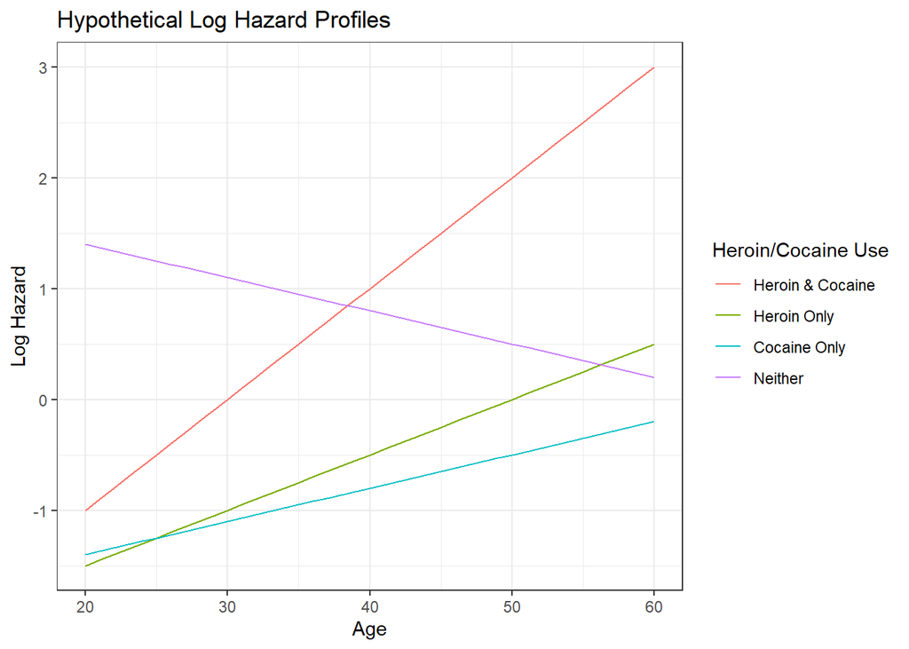

   ```r
   age_seq <- seq(20, 60)
   log_hazard <- data.frame(
     age = rep(age_seq, 4),
     hc = factor(rep(1:4, each = length(age_seq)), labels = c("Heroin & Cocaine", "Heroin Only", "Cocaine Only", "Neither")),
     log_hazard = c(
       0.1 * age_seq - 3,  # HC = 1 (Steep increase)
       0.05 * age_seq - 2.5,  # HC = 2 (Moderate increase)
       0.03 * age_seq - 2,  # HC = 3 (Slight increase)
       -0.03 * age_seq + 2  # HC = 4 (Slight decrease)
     )
   )

   ggplot(log_hazard, aes(x = age, y = log_hazard, color = hc)) +
     geom_line() +
     labs(title = "Hypothetical Log Hazard Profiles",
          x = "Age",
          y = "Log Hazard",
          color = "Heroin/Cocaine Use") +
     theme_bw()
   ```

2. Based on the output, determine if the overall model is significant at the .05 level. State the appropriate  
   null and alternative hypotheses, report the correct test statistic and p-value, and state a conclusion  
   in context.

   ```r
   summary(cr.object)
   ```

   ```
   Call:
   coxph(formula = Surv(TIME, CENSOR) ~ as.factor(HC) * AGE + NDRUGTX,
       data = uissurv)

     n= 575, number of events= 464

                           coef exp(coef)  se(coef)      z Pr(>|z|)
   as.factor(HC)2     -1.373104  0.253319  0.776996 -1.767 0.077195 .
   as.factor(HC)3     -1.029934  0.357031  0.775196 -1.329 0.183976
   as.factor(HC)4     -1.851730  0.156965  0.708571 -2.613 0.008966 **
   AGE                -0.057989  0.943661  0.017069 -3.397 0.000681 ***
   NDRUGTX             0.031243  1.031736  0.007992  3.909 9.25e-05 ***
   as.factor(HC)2:AGE  0.042793  1.043722  0.022675  1.887 0.059129 .
   as.factor(HC)3:AGE  0.020937  1.021158  0.024165  0.866 0.386261
   as.factor(HC)4:AGE  0.051010  1.052333  0.021288  2.396 0.016566 *
   ---
   Signif. codes:  0 '***' 0.001 '**' 0.01 '*' 0.05 '.' 0.1 ' ' 1

                      exp(coef) exp(-coef) lower .95 upper .95
   as.factor(HC)2        0.2533     3.9476   0.05524    1.1616
   as.factor(HC)3        0.3570     2.8009   0.07814    1.6314
   as.factor(HC)4        0.1570     6.3708   0.03914    0.6294
   AGE                   0.9437     1.0597   0.91261    0.9758
   NDRUGTX               1.0317     0.9692   1.01570    1.0480
   as.factor(HC)2:AGE    1.0437     0.9581   0.99835    1.0912
   as.factor(HC)3:AGE    1.0212     0.9793   0.97392    1.0707
   as.factor(HC)4:AGE    1.0523     0.9503   1.00933    1.0972

   Concordance= 0.579  (se = 0.014 )
   Likelihood ratio test= 34.71  on 8 df,   p=3e-05
   Wald test            = 37.65  on 8 df,   p=9e-06
   Score (logrank) test = 38.11  on 8 df,   p=7e-06
   ```

     At the 5% level of significance, we can conclude that hc, age, ndrugtx, and the intereaction between hc and age are jointly significantly useful for predicting the hazard of relapse.
3. Examine the output from the fitted model and locate the 95% confidence interval (0.91261, 0.9758).  
   Interpret the interval in context.  
   We are 95% confident that the true hazard of relapse decreases between 2.42% and 8.739% for each year increase in age of the subject, holding hc and ndrugtx constant.
4. Using an appropriate estimated hazard ratio, which individual is at higher risk of relapsing: Indi-  
   vidual 1 who is 30 years old, has previously used both heroin and cocaine, and has had 1 previous  
   drug treatment; or Individual 2 who is 25 years old, has previously used heroin only, and has had 5  
   previous drug treatments. Show your work.

   ```r
   # new_data <- data.frame(HC = c(1, 2), AGE = c(30, 25), NDRUGTX = c(1, 5))
   # coefs <- predict(cr.object, newdata = new_data, type = "terms")
   #
   # coefs
   #
   # exp(sum(coefs[1,]) - sum(coefs[2,]))

   exp(-0.057989 * 30 + 0.031243 * 1) / exp(-0.057989 * 25 - 1.373104 + 0.031243 * 5 + 0.0437 * 25)
   ```

   ```
   [1] 0.8743164
   ```

   ```r
   CI(4, 5, 30-25, 1-5, 1.96, cr.object)
   ```

   See function at beginning of HW for work!

   ```r
   cr.object.reduced <- coxph(Surv(TIME, CENSOR) ~ as.factor(HC)+AGE+NDRUGTX, data = uissurv)

   anova(cr.object, cr.object.reduced)
   ```

   ```
   Analysis of Deviance Table
    Cox model: response is  Surv(TIME, CENSOR)
    Model 1: ~ as.factor(HC) * AGE + NDRUGTX
    Model 2: ~ as.factor(HC) + AGE + NDRUGTX
      loglik  Chisq Df Pr(>|Chi|)
   1 -2645.8
   2 -2649.1 6.6346  3     0.0845 .
   ---
   Signif. codes:  0 '***' 0.001 '**' 0.01 '*' 0.05 '.' 0.1 ' ' 1
   ```

   - $G_l = 6.6346$
   - p-value = 0.0845

     At the 5% level of significance, we can not conclude that the interaction between age and hc significantly improves the goodness-of-fit of the model containing age, hc, and ndrugtx.
7. Fit an alternative model that contains predictors HC, AGE, and BECKTOTA. Using an appropriate test  
   or other means, determine whether this new alternative model or the reduced model in part (f) fits  
   the data better. Justify your answer.

   ```r
   cr.object.alt <- coxph(Surv(TIME, CENSOR) ~ as.factor(HC)+AGE+BECKTOTA, data = uissurv)

   AIC(cr.object.alt, cr.object.reduced)
   ```

   ```
                     df      AIC
   cr.object.alt      5 5318.710
   cr.object.reduced  5 5308.229
   ```

   The reduced model from part (f) is a better fit to the data than the alternative model because the reduced model has a smaller AIC value.
8. Based on the reduced model that was fit in part (f), plot the predictor-adjusted survival curves at  
   each level of HC for patients who are at the median age of 32 years and who have a median number  
   of prior drug treatments of 3 using the syntax (include the plot in your assignment):

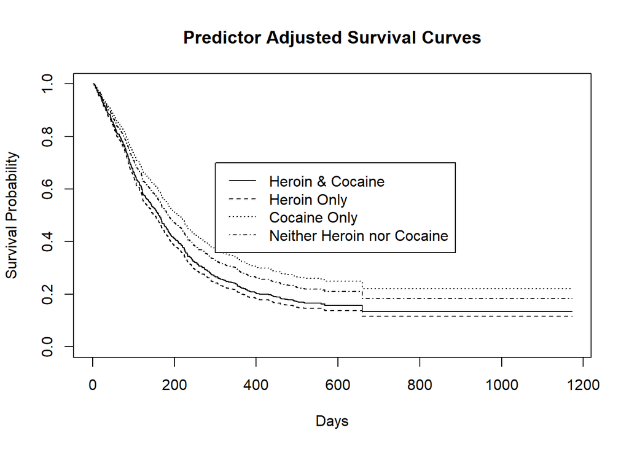

   ```r
   pred.HC <- data.frame(HC=1:4,AGE=median(uissurv$AGE),NDRUGTX=median(uissurv$NDRUGTX))
   pred.HC$HC <- as.factor(pred.HC$HC)
   adj.surv.HC <- survfit(cr.object.reduced,newdata=pred.HC)
   plot(adj.surv.HC,lty=1:4,main="Predictor Adjusted Survival Curves",
   xlab="Days",ylab="Survival Probability")
   legend(300,.7,c("Heroin & Cocaine","Heroin Only","Cocaine Only","Neither Heroin nor Cocaine"),
   lty=1:4)
   ```

   1. Based on the plot, what do you observe about the drug-relapse experiences for participants who  
      are 32 years old with 3 prior drug treatments and who had previously used both heroin and cocaine  
      versus participants (32 years old with 3 prior drug treatments) who had previously used heroin  
      only?

      The survival of individuals who used both heroin and cocaine is slightly greater than the survival of individuals who only used heroin for all time t.
   2. Based on the plot, which group (drug-users) tends to have the longest time until relapse?

      Individuals who only used cocaine tended to have the longest time until relapse since this group has the highest survival probability at all time t.

# Variable Descriptions

| Variable | Description | Codes/Values |
| --- | --- | --- |
| ID | Identification Code | 1 - 628 |
| AGE | Age at Enrollment | Years |
| BECKTOTA | Beck Depression Score | 0 - 54 (higher = more depressed) |
| HC | Heroin/Cocaine Use | 1 = Heroin & Cocaine, 2 = Heroin Only, 3 = Cocaine Only, 4 = Neither |
| IVHX | History of IV Drug Use | 1 = Never, 2 = Previous, 3 = Recent |
| NDRUGTX | Prior Drug Treatments | 0 - 40 |
| RACE | Subject’s Race | 0 = White, 1 = Non-White |
| TREAT | Treatment Assignment | 0 = Short, 1 = Long |
| SITE | Treatment Site | 0 = A, 1 = B |
| LOS | Length of Stay | Days |
| TIME | Time to Drug Relapse | Days |
| CENSOR | Censoring status | 1 = Returned to Drugs, 0 = Censored |